# Risk Factor Analysis

## Outcome Variable

**Outcome Variable:** stunted

## Predictor Variables

**Intervention Variable:** mbmi

**Adjustment Set:**

unadjusted

## Stratifying Variables

The analysis was stratified on these variable(s):

- agecat
- studyid
- country

## Data Summary

| agecat | studyid | country | mbmi | stunted | n_cell | n |
| --- | --- | --- | --- | --- | --- | --- |
| Birth | ki0047075b-MAL-ED | BANGLADESH | [18.5-25) | 0 | 130 | 246 |
| Birth | ki0047075b-MAL-ED | BANGLADESH | [18.5-25) | 1 | 28 | 246 |
| Birth | ki0047075b-MAL-ED | BANGLADESH | <18.5 | 0 | 25 | 246 |
| Birth | ki0047075b-MAL-ED | BANGLADESH | <18.5 | 1 | 5 | 246 |
| Birth | ki0047075b-MAL-ED | BANGLADESH | [25-30) | 0 | 47 | 246 |
| Birth | ki0047075b-MAL-ED | BANGLADESH | [25-30) | 1 | 5 | 246 |
| Birth | ki0047075b-MAL-ED | BANGLADESH | >=30 | 0 | 2 | 246 |
| Birth | ki0047075b-MAL-ED | BANGLADESH | >=30 | 1 | 4 | 246 |
| 6 months | ki0047075b-MAL-ED | BANGLADESH | [18.5-25) | 0 | 124 | 241 |
| 6 months | ki0047075b-MAL-ED | BANGLADESH | [18.5-25) | 1 | 29 | 241 |
| 6 months | ki0047075b-MAL-ED | BANGLADESH | <18.5 | 0 | 22 | 241 |
| 6 months | ki0047075b-MAL-ED | BANGLADESH | <18.5 | 1 | 10 | 241 |
| 6 months | ki0047075b-MAL-ED | BANGLADESH | [25-30) | 0 | 48 | 241 |
| 6 months | ki0047075b-MAL-ED | BANGLADESH | [25-30) | 1 | 2 | 241 |
| 6 months | ki0047075b-MAL-ED | BANGLADESH | >=30 | 0 | 2 | 241 |
| 6 months | ki0047075b-MAL-ED | BANGLADESH | >=30 | 1 | 4 | 241 |
| 24 months | ki0047075b-MAL-ED | BANGLADESH | [18.5-25) | 0 | 69 | 212 |
| 24 months | ki0047075b-MAL-ED | BANGLADESH | [18.5-25) | 1 | 65 | 212 |
| 24 months | ki0047075b-MAL-ED | BANGLADESH | <18.5 | 0 | 10 | 212 |
| 24 months | ki0047075b-MAL-ED | BANGLADESH | <18.5 | 1 | 19 | 212 |
| 24 months | ki0047075b-MAL-ED | BANGLADESH | [25-30) | 0 | 34 | 212 |
| 24 months | ki0047075b-MAL-ED | BANGLADESH | [25-30) | 1 | 11 | 212 |
| 24 months | ki0047075b-MAL-ED | BANGLADESH | >=30 | 0 | 1 | 212 |
| 24 months | ki0047075b-MAL-ED | BANGLADESH | >=30 | 1 | 3 | 212 |
| Birth | ki0047075b-MAL-ED | BRAZIL | [18.5-25) | 0 | 62 | 184 |
| Birth | ki0047075b-MAL-ED | BRAZIL | [18.5-25) | 1 | 8 | 184 |
| Birth | ki0047075b-MAL-ED | BRAZIL | <18.5 | 0 | 7 | 184 |
| Birth | ki0047075b-MAL-ED | BRAZIL | <18.5 | 1 | 2 | 184 |
| Birth | ki0047075b-MAL-ED | BRAZIL | [25-30) | 0 | 62 | 184 |
| Birth | ki0047075b-MAL-ED | BRAZIL | [25-30) | 1 | 7 | 184 |

[output cut: 284 more lines]

The following strata were considered:

- agecat: 24 months, studyid: ki0047075b-MAL-ED, country: BANGLADESH
- agecat: 24 months, studyid: ki0047075b-MAL-ED, country: BRAZIL
- agecat: 24 months, studyid: ki0047075b-MAL-ED, country: INDIA
- agecat: 24 months, studyid: ki0047075b-MAL-ED, country: NEPAL
- agecat: 24 months, studyid: ki0047075b-MAL-ED, country: PERU
- agecat: 24 months, studyid: ki0047075b-MAL-ED, country: SOUTH AFRICA
- agecat: 24 months, studyid: ki0047075b-MAL-ED, country: TANZANIA, UNITED REPUBLIC OF
- agecat: 24 months, studyid: ki1017093-NIH-Birth, country: BANGLADESH
- agecat: 24 months, studyid: ki1017093b-PROVIDE, country: BANGLADESH
- agecat: 24 months, studyid: ki1017093c-NIH-Crypto, country: BANGLADESH
- agecat: 24 months, studyid: ki1066203-TanzaniaChild2, country: TANZANIA, UNITED REPUBLIC OF
- agecat: 24 months, studyid: ki1119695-PROBIT, country: BELARUS
- agecat: 24 months, studyid: ki1126311-ZVITAMBO, country: ZIMBABWE
- agecat: 24 months, studyid: ki1148112-LCNI-5, country: MALAWI
- agecat: 6 months, studyid: ki0047075b-MAL-ED, country: BANGLADESH
- agecat: 6 months, studyid: ki0047075b-MAL-ED, country: BRAZIL
- agecat: 6 months, studyid: ki0047075b-MAL-ED, country: INDIA
- agecat: 6 months, studyid: ki0047075b-MAL-ED, country: NEPAL
- agecat: 6 months, studyid: ki0047075b-MAL-ED, country: PERU
- agecat: 6 months, studyid: ki0047075b-MAL-ED, country: SOUTH AFRICA
- agecat: 6 months, studyid: ki0047075b-MAL-ED, country: TANZANIA, UNITED REPUBLIC OF
- agecat: 6 months, studyid: ki1000304b-SAS-CompFeed, country: INDIA
- agecat: 6 months, studyid: ki1017093-NIH-Birth, country: BANGLADESH
- agecat: 6 months, studyid: ki1017093b-PROVIDE, country: BANGLADESH
- agecat: 6 months, studyid: ki1017093c-NIH-Crypto, country: BANGLADESH
- agecat: 6 months, studyid: ki1066203-TanzaniaChild2, country: TANZANIA, UNITED REPUBLIC OF
- agecat: 6 months, studyid: ki1119695-PROBIT, country: BELARUS
- agecat: 6 months, studyid: ki1126311-ZVITAMBO, country: ZIMBABWE
- agecat: 6 months, studyid: ki1148112-LCNI-5, country: MALAWI
- agecat: Birth, studyid: ki0047075b-MAL-ED, country: BANGLADESH
- agecat: Birth, studyid: ki0047075b-MAL-ED, country: BRAZIL
- agecat: Birth, studyid: ki0047075b-MAL-ED, country: INDIA
- agecat: Birth, studyid: ki0047075b-MAL-ED, country: NEPAL
- agecat: Birth, studyid: ki0047075b-MAL-ED, country: PERU
- agecat: Birth, studyid: ki0047075b-MAL-ED, country: SOUTH AFRICA
- agecat: Birth, studyid: ki0047075b-MAL-ED, country: TANZANIA, UNITED REPUBLIC OF
- agecat: Birth, studyid: ki1000304b-SAS-CompFeed, country: INDIA
- agecat: Birth, studyid: ki1017093-NIH-Birth, country: BANGLADESH
- agecat: Birth, studyid: ki1017093c-NIH-Crypto, country: BANGLADESH
- agecat: Birth, studyid: ki1119695-PROBIT, country: BELARUS
- agecat: Birth, studyid: ki1126311-ZVITAMBO, country: ZIMBABWE

### Dropped Strata

Some strata were dropped due to rare outcomes:

- agecat: Birth, studyid: ki0047075b-MAL-ED, country: BANGLADESH
- agecat: 6 months, studyid: ki0047075b-MAL-ED, country: BANGLADESH
- agecat: 24 months, studyid: ki0047075b-MAL-ED, country: BANGLADESH
- agecat: Birth, studyid: ki0047075b-MAL-ED, country: BRAZIL
- agecat: 6 months, studyid: ki0047075b-MAL-ED, country: BRAZIL
- agecat: 24 months, studyid: ki0047075b-MAL-ED, country: BRAZIL
- agecat: Birth, studyid: ki0047075b-MAL-ED, country: INDIA
- agecat: 6 months, studyid: ki0047075b-MAL-ED, country: INDIA
- agecat: 24 months, studyid: ki0047075b-MAL-ED, country: INDIA
- agecat: 6 months, studyid: ki0047075b-MAL-ED, country: NEPAL
- agecat: 24 months, studyid: ki0047075b-MAL-ED, country: NEPAL
- agecat: Birth, studyid: ki0047075b-MAL-ED, country: NEPAL
- agecat: Birth, studyid: ki0047075b-MAL-ED, country: PERU
- agecat: 6 months, studyid: ki0047075b-MAL-ED, country: PERU
- agecat: 24 months, studyid: ki0047075b-MAL-ED, country: PERU
- agecat: Birth, studyid: ki0047075b-MAL-ED, country: SOUTH AFRICA
- agecat: 6 months, studyid: ki0047075b-MAL-ED, country: SOUTH AFRICA
- agecat: 24 months, studyid: ki0047075b-MAL-ED, country: SOUTH AFRICA
- agecat: Birth, studyid: ki0047075b-MAL-ED, country: TANZANIA, UNITED REPUBLIC OF
- agecat: 6 months, studyid: ki0047075b-MAL-ED, country: TANZANIA, UNITED REPUBLIC OF
- agecat: 24 months, studyid: ki0047075b-MAL-ED, country: TANZANIA, UNITED REPUBLIC OF
- agecat: 6 months, studyid: ki1000304b-SAS-CompFeed, country: INDIA
- agecat: Birth, studyid: ki1000304b-SAS-CompFeed, country: INDIA
- agecat: 24 months, studyid: ki1017093-NIH-Birth, country: BANGLADESH
- agecat: Birth, studyid: ki1017093-NIH-Birth, country: BANGLADESH
- agecat: 6 months, studyid: ki1017093b-PROVIDE, country: BANGLADESH
- agecat: 24 months, studyid: ki1017093b-PROVIDE, country: BANGLADESH
- agecat: Birth, studyid: ki1017093c-NIH-Crypto, country: BANGLADESH
- agecat: 6 months, studyid: ki1017093c-NIH-Crypto, country: BANGLADESH
- agecat: 24 months, studyid: ki1017093c-NIH-Crypto, country: BANGLADESH
- agecat: 6 months, studyid: ki1066203-TanzaniaChild2, country: TANZANIA, UNITED REPUBLIC OF
- agecat: 24 months, studyid: ki1066203-TanzaniaChild2, country: TANZANIA, UNITED REPUBLIC OF
- agecat: Birth, studyid: ki1119695-PROBIT, country: BELARUS
- agecat: 6 months, studyid: ki1148112-LCNI-5, country: MALAWI
- agecat: 24 months, studyid: ki1148112-LCNI-5, country: MALAWI

## Methods Detail

We’re interested in the causal parameters $E[Y_a]$ for all values of $a \in \mathcal{A}$. These parameters represent the mean outcome if, possibly contrary to fact, we intervened to set all units to have $A=a$. Under the randomization and positivity assumptions, these are identified by the statistical parameters $\psi_a=E_W[E_{Y|A,W}(Y|A=a,W)]$. In addition, we’re interested in the mean of $Y$, $E[Y]$ under no intervention (the observed mean). We will estimate these parameters by using SuperLearner to fit the relevant likelihood factors – $E_{Y|A,W}(Y|A=a,W)$ and $p(A=a|W)$, and then updating our likelihood fit using a joint TMLE.

For unadjusted analyses ($W=\{\}$), initial likelihoods were estimated using Lrnr_glm to estimate the simple $E(Y|A)$ and Lrnr_mean to estimate $p(A)$. For adjusted analyses, a small library containing Lrnr_glmnet, Lrnr_xgboost, and Lrnr_mean was used.

Having estimated these parameters, we will then use the delta method to estimate relative risks and attributable risks relative to a prespecified baseline level of $A$.

# Results Detail

## Results Plots

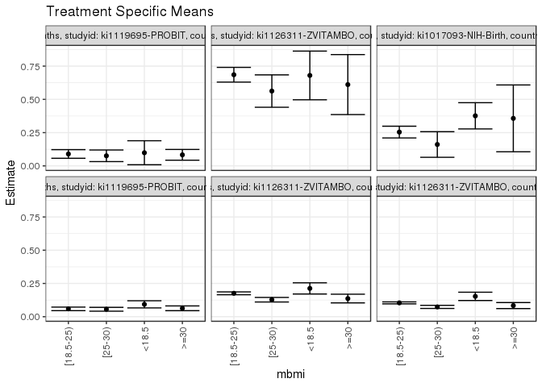

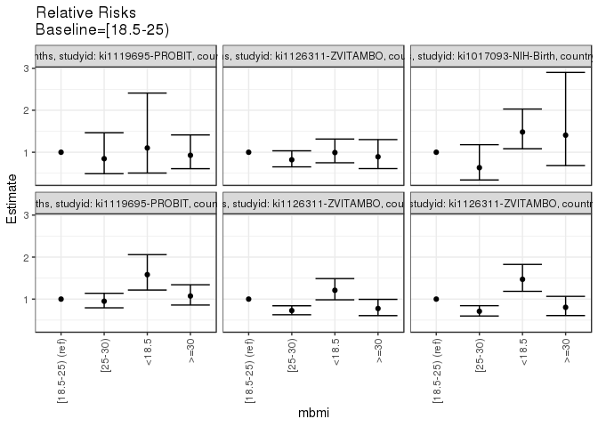

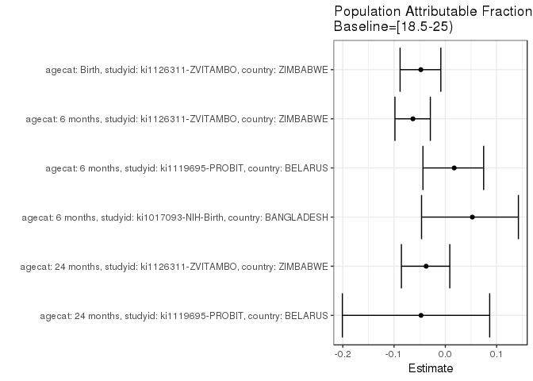

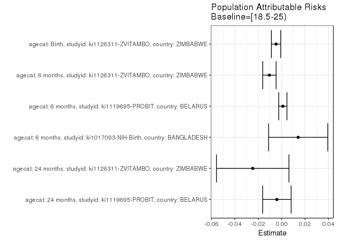

## Results Table

### Parameter: TSM

| agecat | studyid | country | intervention_level | baseline_level | estimate | ci_lower | ci_upper |
| --- | --- | --- | --- | --- | --- | --- | --- |
| Birth | ki1126311-ZVITAMBO | ZIMBABWE | [18.5-25) | NA | 0.1039709 | 0.0966058 | 0.1113360 |
| Birth | ki1126311-ZVITAMBO | ZIMBABWE | <18.5 | NA | 0.1529412 | 0.1217016 | 0.1841807 |
| Birth | ki1126311-ZVITAMBO | ZIMBABWE | [25-30) | NA | 0.0737705 | 0.0621739 | 0.0853671 |
| Birth | ki1126311-ZVITAMBO | ZIMBABWE | >=30 | NA | 0.0836237 | 0.0609764 | 0.1062710 |
| 6 months | ki1017093-NIH-Birth | BANGLADESH | [18.5-25) | NA | 0.2540107 | 0.2098527 | 0.2981687 |
| 6 months | ki1017093-NIH-Birth | BANGLADESH | <18.5 | NA | 0.3763441 | 0.2777896 | 0.4748986 |
| 6 months | ki1017093-NIH-Birth | BANGLADESH | [25-30) | NA | 0.1607143 | 0.0644332 | 0.2569954 |
| 6 months | ki1017093-NIH-Birth | BANGLADESH | >=30 | NA | 0.3571429 | 0.1059154 | 0.6083703 |
| 6 months | ki1119695-PROBIT | BELARUS | [18.5-25) | NA | 0.0588387 | 0.0454760 | 0.0722015 |
| 6 months | ki1119695-PROBIT | BELARUS | <18.5 | NA | 0.0930693 | 0.0662215 | 0.1199172 |
| 6 months | ki1119695-PROBIT | BELARUS | [25-30) | NA | 0.0558542 | 0.0413219 | 0.0703866 |
| 6 months | ki1119695-PROBIT | BELARUS | >=30 | NA | 0.0631506 | 0.0453015 | 0.0809997 |
| 6 months | ki1126311-ZVITAMBO | ZIMBABWE | [18.5-25) | NA | 0.1758763 | 0.1651609 | 0.1865917 |
| 6 months | ki1126311-ZVITAMBO | ZIMBABWE | <18.5 | NA | 0.2127072 | 0.1705488 | 0.2548655 |
| 6 months | ki1126311-ZVITAMBO | ZIMBABWE | [25-30) | NA | 0.1277174 | 0.1106653 | 0.1447695 |
| 6 months | ki1126311-ZVITAMBO | ZIMBABWE | >=30 | NA | 0.1364706 | 0.1038312 | 0.1691100 |
| 24 months | ki1119695-PROBIT | BELARUS | [18.5-25) | NA | 0.0894378 | 0.0568842 | 0.1219914 |
| 24 months | ki1119695-PROBIT | BELARUS | <18.5 | NA | 0.0985915 | 0.0083975 | 0.1887856 |
| 24 months | ki1119695-PROBIT | BELARUS | [25-30) | NA | 0.0756859 | 0.0319977 | 0.1193741 |
| 24 months | ki1119695-PROBIT | BELARUS | >=30 | NA | 0.0829694 | 0.0426321 | 0.1233068 |
| 24 months | ki1126311-ZVITAMBO | ZIMBABWE | [18.5-25) | NA | 0.6851852 | 0.6297131 | 0.7406573 |
| 24 months | ki1126311-ZVITAMBO | ZIMBABWE | <18.5 | NA | 0.6800000 | 0.4969017 | 0.8630983 |
| 24 months | ki1126311-ZVITAMBO | ZIMBABWE | [25-30) | NA | 0.5625000 | 0.4408015 | 0.6841985 |
| 24 months | ki1126311-ZVITAMBO | ZIMBABWE | >=30 | NA | 0.6111111 | 0.3856034 | 0.8366188 |

### Parameter: E(Y)

| agecat | studyid | country | intervention_level | baseline_level | estimate | ci_lower | ci_upper |
| --- | --- | --- | --- | --- | --- | --- | --- |
| Birth | ki1126311-ZVITAMBO | ZIMBABWE | NA | NA | 0.0992319 | 0.0932615 | 0.1052022 |
| 6 months | ki1017093-NIH-Birth | BANGLADESH | NA | NA | 0.2681564 | 0.2306532 | 0.3056597 |
| 6 months | ki1119695-PROBIT | BELARUS | NA | NA | 0.0598756 | 0.0470544 | 0.0726968 |
| 6 months | ki1126311-ZVITAMBO | ZIMBABWE | NA | NA | 0.1654241 | 0.1567862 | 0.1740620 |
| 24 months | ki1119695-PROBIT | BELARUS | NA | NA | 0.0853933 | 0.0554084 | 0.1153781 |
| 24 months | ki1126311-ZVITAMBO | ZIMBABWE | NA | NA | 0.6604775 | 0.6126125 | 0.7083424 |

### Parameter: RR

| agecat | studyid | country | intervention_level | baseline_level | estimate | ci_lower | ci_upper |
| --- | --- | --- | --- | --- | --- | --- | --- |
| Birth | ki1126311-ZVITAMBO | ZIMBABWE | [18.5-25) | [18.5-25) | 1.0000000 | 1.0000000 | 1.0000000 |
| Birth | ki1126311-ZVITAMBO | ZIMBABWE | <18.5 | [18.5-25) | 1.4709998 | 1.1850072 | 1.8260147 |
| Birth | ki1126311-ZVITAMBO | ZIMBABWE | [25-30) | [18.5-25) | 0.7095302 | 0.5971573 | 0.8430493 |
| Birth | ki1126311-ZVITAMBO | ZIMBABWE | >=30 | [18.5-25) | 0.8042990 | 0.6079156 | 1.0641230 |
| 6 months | ki1017093-NIH-Birth | BANGLADESH | [18.5-25) | [18.5-25) | 1.0000000 | 1.0000000 | 1.0000000 |
| 6 months | ki1017093-NIH-Birth | BANGLADESH | <18.5 | [18.5-25) | 1.4816072 | 1.0819925 | 2.0288125 |
| 6 months | ki1017093-NIH-Birth | BANGLADESH | [25-30) | [18.5-25) | 0.6327068 | 0.3390716 | 1.1806291 |
| 6 months | ki1017093-NIH-Birth | BANGLADESH | >=30 | [18.5-25) | 1.4060150 | 0.6812403 | 2.9018811 |
| 6 months | ki1119695-PROBIT | BELARUS | [18.5-25) | [18.5-25) | 1.0000000 | 1.0000000 | 1.0000000 |
| 6 months | ki1119695-PROBIT | BELARUS | <18.5 | [18.5-25) | 1.5817691 | 1.2149882 | 2.0592739 |
| 6 months | ki1119695-PROBIT | BELARUS | [25-30) | [18.5-25) | 0.9492766 | 0.7919663 | 1.1378338 |
| 6 months | ki1119695-PROBIT | BELARUS | >=30 | [18.5-25) | 1.0732824 | 0.8587945 | 1.3413398 |
| 6 months | ki1126311-ZVITAMBO | ZIMBABWE | [18.5-25) | [18.5-25) | 1.0000000 | 1.0000000 | 1.0000000 |
| 6 months | ki1126311-ZVITAMBO | ZIMBABWE | <18.5 | [18.5-25) | 1.2094136 | 0.9829312 | 1.4880811 |
| 6 months | ki1126311-ZVITAMBO | ZIMBABWE | [25-30) | [18.5-25) | 0.7261774 | 0.6270560 | 0.8409674 |
| 6 months | ki1126311-ZVITAMBO | ZIMBABWE | >=30 | [18.5-25) | 0.7759465 | 0.6062408 | 0.9931580 |
| 24 months | ki1119695-PROBIT | BELARUS | [18.5-25) | [18.5-25) | 1.0000000 | 1.0000000 | 1.0000000 |
| 24 months | ki1119695-PROBIT | BELARUS | <18.5 | [18.5-25) | 1.1023474 | 0.5043750 | 2.4092586 |
| 24 months | ki1119695-PROBIT | BELARUS | [25-30) | [18.5-25) | 0.8462405 | 0.4893470 | 1.4634258 |
| 24 months | ki1119695-PROBIT | BELARUS | >=30 | [18.5-25) | 0.9276773 | 0.6092126 | 1.4126188 |
| 24 months | ki1126311-ZVITAMBO | ZIMBABWE | [18.5-25) | [18.5-25) | 1.0000000 | 1.0000000 | 1.0000000 |
| 24 months | ki1126311-ZVITAMBO | ZIMBABWE | <18.5 | [18.5-25) | 0.9924324 | 0.7491873 | 1.3146541 |
| 24 months | ki1126311-ZVITAMBO | ZIMBABWE | [25-30) | [18.5-25) | 0.8209459 | 0.6516144 | 1.0342807 |
| 24 months | ki1126311-ZVITAMBO | ZIMBABWE | >=30 | [18.5-25) | 0.8918919 | 0.6112803 | 1.3013197 |

### Parameter: PAR

| agecat | studyid | country | intervention_level | baseline_level | estimate | ci_lower | ci_upper |
| --- | --- | --- | --- | --- | --- | --- | --- |
| Birth | ki1126311-ZVITAMBO | ZIMBABWE | [18.5-25) | NA | -0.0047390 | -0.0086873 | -0.0007908 |
| 6 months | ki1017093-NIH-Birth | BANGLADESH | [18.5-25) | NA | 0.0141457 | -0.0111588 | 0.0394503 |
| 6 months | ki1119695-PROBIT | BELARUS | [18.5-25) | NA | 0.0010369 | -0.0024933 | 0.0045671 |
| 6 months | ki1126311-ZVITAMBO | ZIMBABWE | [18.5-25) | NA | -0.0104522 | -0.0161762 | -0.0047281 |
| 24 months | ki1119695-PROBIT | BELARUS | [18.5-25) | NA | -0.0040446 | -0.0162156 | 0.0081264 |
| 24 months | ki1126311-ZVITAMBO | ZIMBABWE | [18.5-25) | NA | -0.0247077 | -0.0557015 | 0.0062860 |

### Parameter: PAF

| agecat | studyid | country | intervention_level | baseline_level | estimate | ci_lower | ci_upper |
| --- | --- | --- | --- | --- | --- | --- | --- |
| Birth | ki1126311-ZVITAMBO | ZIMBABWE | [18.5-25) | NA | -0.0477570 | -0.0882273 | -0.0087917 |
| 6 months | ki1017093-NIH-Birth | BANGLADESH | [18.5-25) | NA | 0.0527518 | -0.0463760 | 0.1424888 |
| 6 months | ki1119695-PROBIT | BELARUS | [18.5-25) | NA | 0.0173176 | -0.0436444 | 0.0747186 |
| 6 months | ki1126311-ZVITAMBO | ZIMBABWE | [18.5-25) | NA | -0.0631841 | -0.0982616 | -0.0292270 |
| 24 months | ki1119695-PROBIT | BELARUS | [18.5-25) | NA | -0.0473639 | -0.2008294 | 0.0864887 |
| 24 months | ki1126311-ZVITAMBO | ZIMBABWE | [18.5-25) | NA | -0.0374089 | -0.0856609 | 0.0086985 |